# Loss Reserving Aplicacion de modelos lineales generalizados mixtos

## Introduccion

#### Carga de librerias

```r
library(tidyverse)
library(cplm)
```

## Preparacion de datos

### Funciones

Definicion de funciones para el procesamiento de datos.  
Disclaimer: Para un framework generalizado se debera agregar un argumento con el numero de años de desarrollo

```r
# Funcion que lleva los pagos acumulados a incrementales (del triangulo superior izquierdo)
cum_to_inc <- function(matrix){
  g = 1
  while(g < 6){
    for(j in 5:2){
      matrix[g,j] = matrix[g,j] - matrix[g,(j-1)]}
    g = g + 1
  }
  matrix
}

# Funcion que lleva los pagos incrementales a acumulados (para todo el panel de datos).
inc_to_cum <- function(matrix){
  for(i in 1:5){
    for(j in 2:5){
      matrix[i,j] <- matrix[i,j] + matrix[i, j-1]
    }
  }
  matrix
}

# Funcion que elimina los datos del triangulo inferior derecho.
to_triangular <- function(matrix){
  for(i in 5:2){
    for(j in (7-i):5){
      matrix[i,j] <- NA
    }
  }
  matrix
}

# Funcion que calcula los factores de desarrollo (volume weighted link ratio)

link_ratios <- function(triangle){
  link_ratios_vector <- c()
  for(i in 1:4){
    link_ratios_vector[i] <- sum(triangle[,i+1], na.rm = TRUE) / sum(triangle[-6+i,i], na.rm = TRUE)
  }
  link_ratios_vector
}

# Funcion que calcula los factores de desarrollo acumulados.

fda <- function(link_ratios){
  fda_vector <- link_ratios
  for(i in 3:1){
    fda_vector[i] = fda_vector[i]*fda_vector[i+1]
  }
  fda_vector
}

# Funcion que calcula ultimate losses a partir de los factores de desarrollo acumulados.

cl_ult <- function(fda, triangle){
  cl_ult_vector <- c()
  for(i in 1:4){
    cl_ult_vector[i] <- triangle[6-i,i] * fda[i]
  }
  cl_ult_vector[5] <- triangle[1,5]
  cl_ult_tbl <- tibble( year = 2011:2007, ult = cl_ult_vector) %>% column_to_rownames('year') %>% t()
  cl_ult_tbl <- cl_ult_tbl[,5:1]
  cl_ult_tbl
}

# Funcion que calcula IBNR a partir de ultimates y triangulo de stros incurridos acumulados.

cl_ibnr <- function(ult, triangle){
  cl_ibnr_vector <- c()
  for(i in 1:5){
    cl_ibnr_vector[i] <- ult[i] - triangle[i, 6-i]
  }
  cl_ibnr_tbl <- tibble(year = 2007:2011, ibnr = cl_ibnr_vector) %>% column_to_rownames('year') %>% t()
  cl_ibnr_tbl
}
```

### Extraccion de datos

Se obtienen los datos agregados de los siniestros incurridos para el hecho generador daño total con 5 años de desarrollo para cada año de accidente, suponiendo que no se desarrolla posteriormente al plazo fijado por cuestiones de practicidad en la futura evaluacion de los modelos.  
Fuente: Superintendecia de Seguros de la Nacion.

```r
data_2011 <- readxl::read_excel("ssn_20162017_desarrollo_siniestros_automotores.xlsx", sheet = 8)[15,c(7,11,15,19,23)]
data_2010 <- readxl::read_excel("ssn_20162017_desarrollo_siniestros_automotores.xlsx", sheet = 9)[15,c(7,11,15,19,23)]
data_2009 <- readxl::read_excel("ssn_20162017_desarrollo_siniestros_automotores.xlsx", sheet = 10)[15,c(7,11,15,19,23)]
data_2008 <- readxl::read_excel("ssn_20162017_desarrollo_siniestros_automotores.xlsx", sheet = 11)[15,c(7,11,15,19,23)]
data_2007 <- readxl::read_excel("ssn_20162017_desarrollo_siniestros_automotores.xlsx", sheet = 12)[15,c(7,11,15,19,23)]
```

Definicion de la matriz de datos.

```r
# Ingreso de los datos al formato matriz.
matrix_data <- matrix(c(data_2007,data_2008,data_2009,data_2010,data_2011), 5, 5, byrow = TRUE)
rownames(matrix_data) <- c(2007:2011)
colnames(matrix_data) <- c(1:5)

# Conversion de matriz a panel de datos y definicion de las variables de la matriz como numericas.
original_df <- as.data.frame(matrix_data) %>%
  mutate_all(list(~as.numeric(.)))

print(original_df)
```

```
##              1         2         3         4         5
## 2007 148813736 176967325 182322296 184720805 186305863
## 2008 214207675 243243446 245747845 246895034 250562475
## 2009 277701790 306262288 309431146 312180892 317792087
## 2010 379729035 418197059 425606330 427164647 429384417
## 2011 535269655 596996475 597771588 606862602 616582626
```

```r
# Obtencion del triangulo de siniestros incurridos acumulados.
cum_triangle <- original_df %>% to_triangular()
```

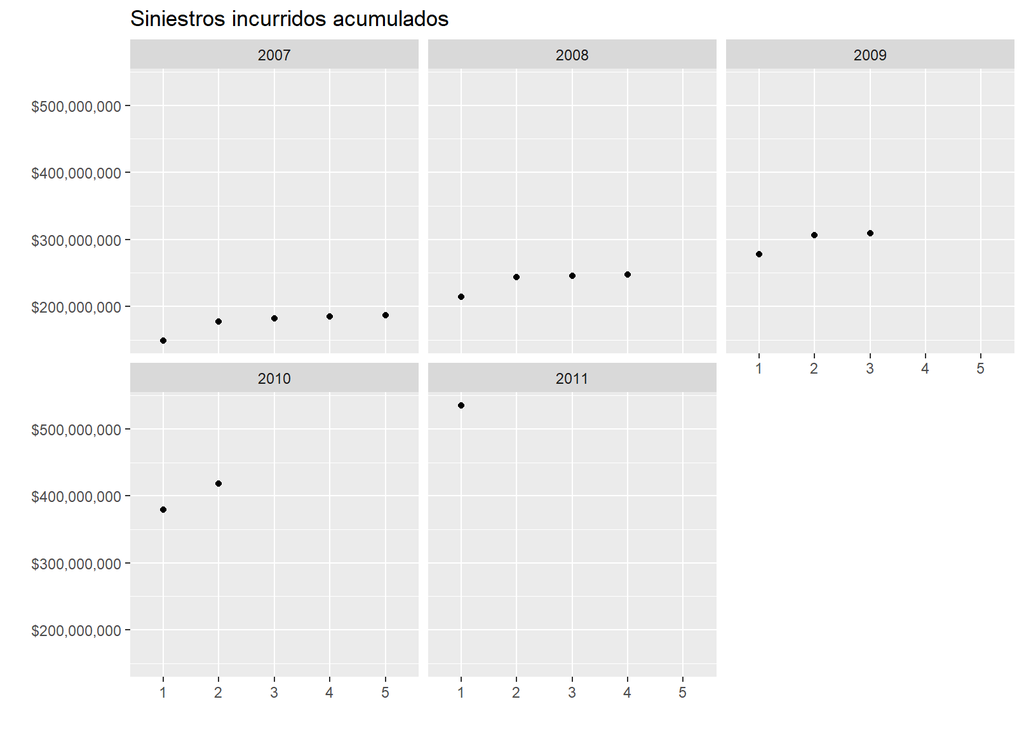

```r
original_df %>%
  to_triangular() %>%
  rownames_to_column("accidente") %>%
  as_tibble() %>%
  gather(key = "desarrollo", value = "valor", -accidente, factor_key = TRUE) %>%
  mutate_at(vars(accidente), list(~factor(.))) %>%
  ggplot(aes(desarrollo, valor)) +
  geom_point() +
  scale_y_continuous(labels = scales::dollar) +
  ylab("") +
  xlab("") +
  ggtitle("Siniestros incurridos acumulados") +
  facet_wrap(~accidente)
```

### Procesamiento de datos

#### Training data: datos para ajustar los modelos

Se utilizaran siniestros incurridos incrementales.

```r
# Siniestros incurridos acumulados a incrementales
inc_data <- cum_to_inc(original_df)

# Obtenemos, entonces, el triangulo de siniestros incurridos incrementales
triangular_inc_data <- to_triangular(inc_data)

# Definicion de a&ntilde;o de accidente y a&ntilde;o de desarrollo como variables categoricas, y de los siniestros incurridos incrementales como variable respuesta.
long_data <- triangular_inc_data %>%
  rownames_to_column("accidente") %>%
  as_tibble() %>%
  gather(key = "desarrollo", value = "valor", -accidente, factor_key = TRUE) %>%
  mutate_at(vars(accidente), list(~factor(.)))

# Division de los datos: Aquellos de registro previo a la fecha de valuacion se utilizaran para ajustar los modelos. Los datos futuros seran utilizados para la posterior evaluacion de los modelos expuestos en este trabajo.
data_fit <- subset(long_data, !is.na(long_data$valor))
data_out <- subset(long_data, is.na(long_data$valor))

print(triangular_inc_data)
```

```
##              1        2       3       4       5
## 2007 148813736 28153588 5354971 2398509 1585057
## 2008 214207675 29035771 2504398 1147189      NA
## 2009 277701790 28560498 3168858      NA      NA
## 2010 379729035 38468023      NA      NA      NA
## 2011 535269655       NA      NA      NA      NA
```

#### Testing data: datos para la evaluacion del modelo

Se utilizaran los datos de siniestros incurridos posteriores a la fecha de valuacion.

```r
# Ingreso de datos a panel largo.
long_test_data <- inc_data %>%
  rownames_to_column("accidente") %>%
  as_tibble() %>%
  gather(key = "desarrollo", value = "valor", -accidente, factor_key = TRUE) %>%
  mutate_at(vars(accidente), list(~factor(.))) %>%
  subset(is.na(long_data$valor))

# Ingreso de los datos en un panel triangular.
triangular_test_data <- long_test_data %>%
  bind_rows(data_fit %>% mutate(valor = NA)) %>%
  spread(desarrollo, valor) %>%
  column_to_rownames('accidente')

# Datos posteriores a la fecha de valuacion de los siniestros incurridos por a&ntilde;o de accidente, i.e, 'real loss per accident year'.
real_loss_paccy <- rowSums(triangular_test_data, na.rm = TRUE)

print(triangular_test_data)
```

```
##       1        2         3       4       5
## 2007 NA       NA        NA      NA      NA
## 2008 NA       NA        NA      NA 3667441
## 2009 NA       NA        NA 2749746 5611195
## 2010 NA       NA 7409271.1 1558317 2219770
## 2011 NA 61726819  775113.7 9091013 9720024
```

Agrupados por año de accidente:

```r
print(real_loss_paccy)
```

```
##     2007     2008     2009     2010     2011
##        0  3667441  8360941 11187358 81312971
```

## Modelos

En esta seccion se utilizara el metodo de Chain Ladder y se ajustaran modelos lineales generalizados mixtos con distintas distribuciones (Poisson con sobredispersion, tweedie con 1 < p < 2, Normal) y enlace logaritmico.

#### Chain Ladder: volume weighted link ratios.

```r
vw_link_ratios <- link_ratios(cum_triangle)
cum_link_ratios <- fda(vw_link_ratios)
cl_ult_losses <- cl_ult(cum_link_ratios, cum_triangle)
```

#### Modelo lineal generalizado mixto: Overdispersed Poisson con enlace logaritmico.

Este modelo tradicional arroja los mismos resultados de estimacion de reservas IBNR que el modelo de Chain Ladder.

```r
# Ajuste del modelo
glm_odp <- glm(valor ~ desarrollo + accidente, family = statmod::tweedie(var.power = 1, link.power = 0), data_fit)

# Datos de prediccion del modelo
glm_odp_prediction <- predict(glm_odp, newdata = data_out, type = "response")
glm_odp_prediction_df <- data_out %>%
  select(-valor) %>%
  bind_cols(as.data.frame(glm_odp_prediction))

# Triangulo inferior derecho de siniestros incurridos incrementales estimados.
glm_odp_triangle <- glm_odp_prediction_df %>%
  rename(valor = glm_odp_prediction) %>%
  bind_rows(data_fit %>%
              mutate(valor = NA)) %>%
  spread(desarrollo, valor) %>%
  column_to_rownames('accidente')


print(glm_odp_triangle)
```

```
##       1        2       3       4       5
## 2007 NA       NA      NA      NA      NA
## 2008 NA       NA      NA      NA 2118564
## 2009 NA       NA      NA 2563014 2677168
## 2010 NA       NA 6348442 3516504 3673126
## 2011 NA 65157447 9114786 5048826 5273697
```

#### Modelo lineal generalizado mixto: Tweedie con enlace logaritmico.

```r
# Ajuste del modelo
glm_tw <- cpglm(valor ~ desarrollo + accidente, link = 0, data_fit)

# Datos de prediccion del modelo
glm_tw_prediction <- predict(glm_tw, newdata = data_out, type = "response")
glm_tw_prediction_df <- data_out %>%
  select(-valor) %>%
  bind_cols(as.data.frame(glm_tw_prediction))

# Triangulo inferior derecho de siniestros incurridos incrementales estimados.
glm_tw_triangle <- glm_tw_prediction_df %>%
  rename(valor = glm_tw_prediction) %>%
  bind_rows(data_fit %>%
              mutate(valor = NA)) %>%
  spread(desarrollo, valor) %>%
  column_to_rownames('accidente')

# Parametro p estimado:
print(glm_tw$p)
```

```
## [1] 1.013862
```

```r
print(glm_tw_triangle)
```

```
##       1        2       3       4       5
## 2007 NA       NA      NA      NA      NA
## 2008 NA       NA      NA      NA 2112922
## 2009 NA       NA      NA 2561243 2668607
## 2010 NA       NA 6352432 3514892 3662233
## 2011 NA 65218446 9125919 5049502 5261172
```

#### Modelo lineal generalizado mixto: Normal con enlace logaritmico.

```r
# Ajuste del modelo
glm_nor <- glm(valor ~ desarrollo + accidente, family = statmod::tweedie(var.power = 0, link.power = 0), data_fit)

# Datos de prediccion del modelo
glm_nor_prediction <- predict(glm_nor, newdata = data_out, type = "response")
glm_nor_prediction_df <- data_out %>%
  select(-valor) %>%
  bind_cols(as.data.frame(glm_nor_prediction))

# Triangulo inferior derecho de siniestros incurridos incrementales estimados.
glm_nor_triangle <- glm_nor_prediction_df %>%
  rename(valor = glm_nor_prediction) %>%
  bind_rows(data_fit %>%
              mutate(valor = NA)) %>%
  spread(desarrollo, valor) %>%
  column_to_rownames('accidente')


print(glm_nor_triangle)
```

```
##       1        2       3       4       5
## 2007 NA       NA      NA      NA      NA
## 2008 NA       NA      NA      NA 2266907
## 2009 NA       NA      NA 2450180 2928143
## 2010 NA       NA 5784650 3349984 4003474
## 2011 NA 60990635 8165708 4728892 5651370
```

## Evaluacion de los modelos

#### Comparacion entre reservas IBNR estimadas y datos reales

Reservas IBNR estimadas de cada modelo:

```r
# Reservas IBNR estimadas por a&ntilde;o de accidente: Chain Ladder deterministico.
cl_IBNR <- cl_ibnr(cl_ult_losses, cum_triangle) %>% as.data.frame() %>% remove_rownames()

# Reservas IBNR estimadas por a&ntilde;o de accidente: modelo GLMM distribucion Poisson con sobredispersion y enlace logartimico.
glm_odp_IBNR <- rowSums(glm_odp_triangle, na.rm = TRUE)

# Reservas IBNR estimadas por a&ntilde;o de accidente: modelo GLMM distribucion Tweedie con p = 1.013862 y enlace logartimico.
glm_tw_IBNR <- rowSums(glm_tw_triangle, na.rm = TRUE)

# Reservas IBNR estimadas por a&ntilde;o de accidente: modelo GLMM distribucion Normal y enlace logartimico.
glm_nor_IBNR <- rowSums(glm_nor_triangle, na.rm = TRUE)

print(tibble(2007:2011, as.numeric(cl_IBNR), glm_odp_IBNR, glm_tw_IBNR, glm_nor_IBNR, .rows= 5) %>%
        rename(accident_year = "2007:2011", cl_IBNR = "as.numeric(cl_IBNR)"))
```

```
## # A tibble: 5 x 5
##   accident_year   cl_IBNR glm_odp_IBNR glm_tw_IBNR glm_nor_IBNR
##           <int>     <dbl>        <dbl>       <dbl>        <dbl>
## 1          2007        0            0           0            0
## 2          2008  2118564.     2118564.    2112922.     2266907.
## 3          2009  5240182.     5240182.    5229850.     5378323.
## 4          2010 13538073.    13538073.   13529557.    13138109.
## 5          2011 84594756.    84594756.   84655040.    79536605.
```

Las reservas IBNR estimadas por el metodo de Chain Ladder son las mismas que por el metodo GLMM con distribucion Poisson con sobredispersion y enlace logaritmico.

Calculo de ‘Mean Absolute Percentage Error (MAPE)’.

```r
# Calculo del 'MAPE' (Mean Absolute Percentage Error) de Reservas IBNR estimadas por Chain Ladder.
# Error porcentual
cl_IBNR_pct_error <- ((as.numeric(cl_IBNR) - real_loss_paccy)/real_loss_paccy)
# Promedio de los errores absolutos porcentuales, i.e, MAPE.
cl_MAPE_IBNR <- sum(abs(cl_IBNR_pct_error), na.rm = TRUE)/4

# Calculo del 'MAPE' (Mean Absolute Percentage Error) de Reservas IBNR estimadas por GLMM ODP.
# Error porcentual
odp_IBNR_pct_error <- ((glm_odp_IBNR - real_loss_paccy)/real_loss_paccy)
# Promedio de los errores absolutos porcentuales, i.e, MAPE.
odp_MAPE_IBNR <- sum(abs(odp_IBNR_pct_error), na.rm = TRUE)/4

# Calculo del 'MAPE' (Mean Absolute Percentage Error) de reservas IBNR estimadas por GLLM Tweedie 1<p<2.
# Error porcentual
tw_pct_error <- ((glm_tw_IBNR - real_loss_paccy)/real_loss_paccy)
# Promedio de los errores absolutos porcentuales, i.e, MAPE.
tw_MAPE_IBNR <- sum(abs(tw_pct_error), na.rm = TRUE)/4

# Calculo del 'MAPE' (Mean Absolute Percentage Error) de reservas IBNR estimadaspor GLLM Normal.
# Error porcentual
nor_pct_error <- ((glm_nor_IBNR - real_loss_paccy)/real_loss_paccy)
# Promedio de los errores absolutos porcentuales, i.e, MAPE.
nor_MAPE_IBNR <- sum(abs(nor_pct_error), na.rm = TRUE)/4

print(tibble(cl_MAPE_IBNR, odp_MAPE_IBNR, tw_MAPE_IBNR, nor_MAPE_IBNR))
```

```
## # A tibble: 1 x 4
##   cl_MAPE_IBNR odp_MAPE_IBNR tw_MAPE_IBNR nor_MAPE_IBNR
##          <dbl>         <dbl>        <dbl>         <dbl>
## 1        0.262         0.262        0.262         0.234
```

Calculo de ‘Root Mean Squared Error (RMSE)’.

```r
cl_RMSE_IBNR <- sqrt(sum((as.numeric(cl_IBNR) - real_loss_paccy)^2)/4)
odp_RMSE_IBNR <- sqrt(sum((glm_odp_IBNR - real_loss_paccy)^2)/4)
tw_RMSE_IBNR <- sqrt(sum((glm_tw_IBNR - real_loss_paccy)^2)/4)
nor_RMSE_IBNR <- sqrt(sum((glm_nor_IBNR - real_loss_paccy)^2)/4)

print(tibble(cl_RMSE_IBNR, odp_RMSE_IBNR, tw_RMSE_IBNR, nor_RMSE_IBNR))
```

```
## # A tibble: 1 x 4
##   cl_RMSE_IBNR odp_RMSE_IBNR tw_RMSE_IBNR nor_RMSE_IBNR
##          <dbl>         <dbl>        <dbl>         <dbl>
## 1     2666184.      2666184.     2686800.      2110593.
```

#### Comparacion de las estimaciones de los siniestros incurridos incrementales con los datos reales

Siniestros incurridos incrementales de cada modelo:

```r
glm_odp_pred <- glm_odp_triangle %>%
  rownames_to_column(var = 'accidente') %>%
  as_tibble() %>%
  gather(key = "desarrollo", value = "valor", -accidente, factor_key = TRUE) %>%
  subset(!is.na(valor))

glm_tw_pred <- glm_tw_triangle %>%
  rownames_to_column(var = 'accidente') %>%
  as_tibble() %>%
  gather(key = "desarrollo", value = "valor", -accidente, factor_key = TRUE) %>%
  subset(!is.na(valor))

glm_nor_pred <- glm_nor_triangle %>%
  rownames_to_column(var = 'accidente') %>%
  as_tibble() %>%
  gather(key = "desarrollo", value = "valor", -accidente, factor_key = TRUE) %>%
  subset(!is.na(valor))

full_data_pred <- long_test_data %>%
  full_join(glm_odp_pred %>% rename(glm_odp_pred = valor),
            by = c('accidente', 'desarrollo')) %>%
  full_join(glm_tw_pred %>% rename(glm_tw_pred = valor),
            by = c('accidente', 'desarrollo')) %>%
  full_join(glm_nor_pred %>% rename(glm_nor_pred = valor),
            by = c('accidente', 'desarrollo'))

print(full_data_pred)
```

```
## # A tibble: 10 x 6
##    accidente desarrollo     valor glm_odp_pred glm_tw_pred glm_nor_pred
##    <chr>     <fct>          <dbl>        <dbl>       <dbl>        <dbl>
##  1 2011      2          61726819.    65157447.   65218446.    60990635.
##  2 2010      3           7409271.     6348442.    6352432.     5784650.
##  3 2011      3            775114.     9114786.    9125919.     8165708.
##  4 2009      4           2749746.     2563014.    2561243.     2450180.
##  5 2010      4           1558317.     3516504.    3514892.     3349984.
##  6 2011      4           9091013.     5048826.    5049502.     4728892.
##  7 2008      5           3667441.     2118564.    2112922.     2266907.
##  8 2009      5           5611195.     2677168.    2668607.     2928143.
##  9 2010      5           2219770.     3673126.    3662233.     4003474.
## 10 2011      5           9720024.     5273697.    5261172.     5651370.
```

## Visualizacion de los datos de prediccion

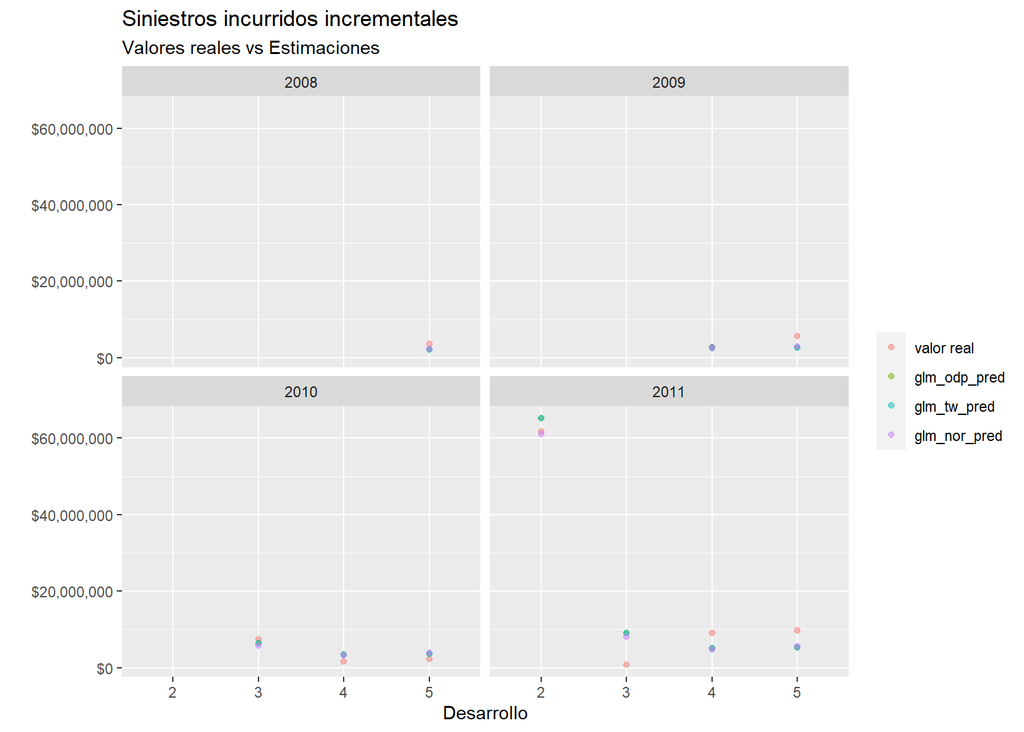

```r
plot_pred <- full_data_pred %>%
  rename("valor real" = valor) %>%
  gather(key = "tipo_dato", value = "valores",
         c("valor real", "glm_odp_pred", "glm_tw_pred", "glm_nor_pred"),
         factor_key = TRUE) %>%
  ggplot(aes(desarrollo, valores, color = tipo_dato))

plot_pred + geom_point(alpha = 0.5) +
  scale_y_continuous(labels = scales::dollar) +
  facet_wrap(~accidente) +
  ggtitle("Siniestros incurridos incrementales", subtitle = "Valores reales vs Estimaciones") +
  ylab("") +
  xlab("Desarrollo") +
  theme(legend.title = element_blank())
```

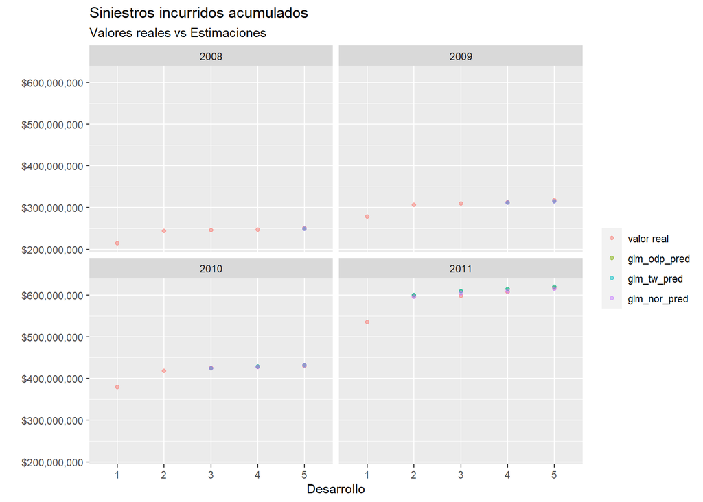

```r
odp_cum <- inc_data %>%
  rownames_to_column("accidente") %>%
  as_tibble() %>%
  gather(key = "desarrollo", value = "valor", -accidente, factor_key = TRUE) %>%
  mutate_at(vars(accidente), list(~factor(.))) %>%
  subset(!is.na(long_data$valor)) %>%
  bind_rows(glm_odp_triangle %>%
              rownames_to_column("accidente") %>%
              as_tibble() %>%
              gather(key = "desarrollo", value = "valor", -accidente, factor_key = TRUE) %>%
              subset(is.na(long_data$valor))
            ) %>%
  spread(desarrollo, valor) %>%
  column_to_rownames("accidente") %>%
  inc_to_cum() %>%
  rownames_to_column("accidente") %>%
  gather(key = "desarrollo", value = "glm_odp_pred", -accidente, factor_key = TRUE) %>%
  subset(is.na(long_data$valor))

tw_cum <- inc_data %>%
  rownames_to_column("accidente") %>%
  as_tibble() %>%
  gather(key = "desarrollo", value = "valor", -accidente, factor_key = TRUE) %>%
  mutate_at(vars(accidente), list(~factor(.))) %>%
  subset(!is.na(long_data$valor)) %>%
  bind_rows(glm_tw_triangle %>%
              rownames_to_column("accidente") %>%
              as_tibble() %>%
              gather(key = "desarrollo", value = "valor", -accidente, factor_key = TRUE) %>%
              subset(is.na(long_data$valor))
  ) %>%
  spread(desarrollo, valor) %>%
  column_to_rownames("accidente") %>%
  inc_to_cum() %>%
  rownames_to_column("accidente") %>%
  gather(key = "desarrollo", value = "glm_tw_pred", -accidente, factor_key = TRUE) %>%
  subset(is.na(long_data$valor))

nor_cum <- inc_data %>%
  rownames_to_column("accidente") %>%
  as_tibble() %>%
  gather(key = "desarrollo", value = "valor", -accidente, factor_key = TRUE) %>%
  mutate_at(vars(accidente), list(~factor(.))) %>%
  subset(!is.na(long_data$valor)) %>%
  bind_rows(glm_nor_triangle %>%
              rownames_to_column("accidente") %>%
              as_tibble() %>%
              gather(key = "desarrollo", value = "valor", -accidente, factor_key = TRUE) %>%
              subset(is.na(long_data$valor))
  ) %>%
  spread(desarrollo, valor) %>%
  column_to_rownames("accidente") %>%
  inc_to_cum() %>%
  rownames_to_column("accidente") %>%
  gather(key = "desarrollo", value = "glm_nor_pred", -accidente, factor_key = TRUE) %>%
  subset(is.na(long_data$valor))

plot_cum_data <-  original_df %>%
  rownames_to_column("accidente") %>%
  as_tibble() %>%
  gather(key = "desarrollo", value = "valor real", -accidente, factor_key = TRUE) %>%
  mutate_at(vars(accidente), list(~factor(.))) %>%
  full_join(odp_cum, by = c('accidente', 'desarrollo')) %>%
  full_join(tw_cum, by = c('accidente', 'desarrollo')) %>%
  full_join(nor_cum, by = c('accidente', 'desarrollo')) %>%
  gather(key = "tipo_dato", value = "valores",
         c("valor real", "glm_odp_pred", "glm_tw_pred", "glm_nor_pred"),
         factor_key = TRUE) %>%
  filter(accidente != "2007") %>%
  ggplot(aes(desarrollo, valores, color=tipo_dato))

plot_cum_data +
  geom_point(alpha = 0.5) +
  scale_y_continuous(labels = scales::dollar) +
  facet_wrap(~accidente) +
  ggtitle("Siniestros incurridos acumulados", subtitle = "Valores reales vs Estimaciones") +
  ylab("") +
  xlab("Desarrollo") +
  theme(legend.title = element_blank())
```

## Conclusiones

Ademas, se corroboro que el modelo de Chain Ladder con factores de desarrollo calculados mediante promedio ponderado da los mismos resultados que el Modelo Lineal Generalizado Mixto con distribucion Poisson con sobredispersion y enlace logaritmico.  
Luego, cabe destacar que debido a las caracteristicas de la informacion que ofrecen los organismos regulatorios, esto es, en forma agregada y en triangulos, los modelos que pueden ajustarse son escasos:

- En el caso de reproducir una distribucion con “Bootstrapping”, no se puede validar el modelo con un subconjunto de informacion real.
- En la eleccion de modelos no parametricos como, por ejemplo, bosques aleatorios o redes neuronales, no se presupone una distribucion y, por lo tanto, se necesita una gran cantidad de observaciones (muchas mas que en modelos parametricos) para realizar estimaciones con cierto grado de precision (James et. al., 2013). En consecuencia, es necesario obtener informacion individual de los siniestros.